# a3_task3_quin_smith

Quin Smith

11/3/2020

### Summary

This task will use version control, project management, data wrangling, analysis, and visualization to explore data of red and purple urchins recorded by Santa Barbara Coastal Long Term Ecological Research program divers.

Data:

Reed, D. 2020. SBC LTER: Reef: Long-term experiment: Kelp removal: Urchin size frequency distribution ver 20. Environmental Data Initiative. https://doi.org/10.6073/pasta/5a1e9ef03aa47bd2225c0bb98a02a63b

### Read in data

Read in urchin data as `urchins`

```r
urchins <- read.csv(here("data", "urchins.csv"))
```

## Section 1: Comparisons of size (cm) between Red and Purple urchins

### Exploratory data viz

Compare distribution of sizes between purple and red urchins using: - faceted histogram - boxplot

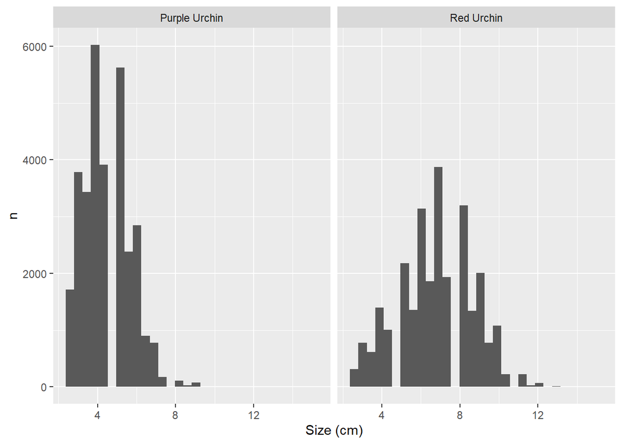

```r
urchins %>%
  ggplot(aes(x = SIZE)) +
  geom_histogram() +
  facet_wrap(~COMMON_NAME) +
  labs(x = "Size (cm)",
       y = "n")
```

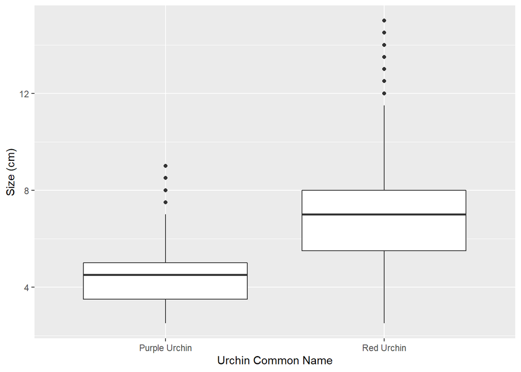

```r
urchins %>%
  ggplot(aes(x = COMMON_NAME, y = SIZE)) +
  geom_boxplot() +
  labs(x = "Urchin Common Name",
       y = "Size (cm)")
```